# Homework 1-DATA 624

2021-05-02

### Exercise 2.1

Use the help function to explore what the series gold, woolyrnq and gas represent.

1. Use autoplot() to plot each of these in separate plots.

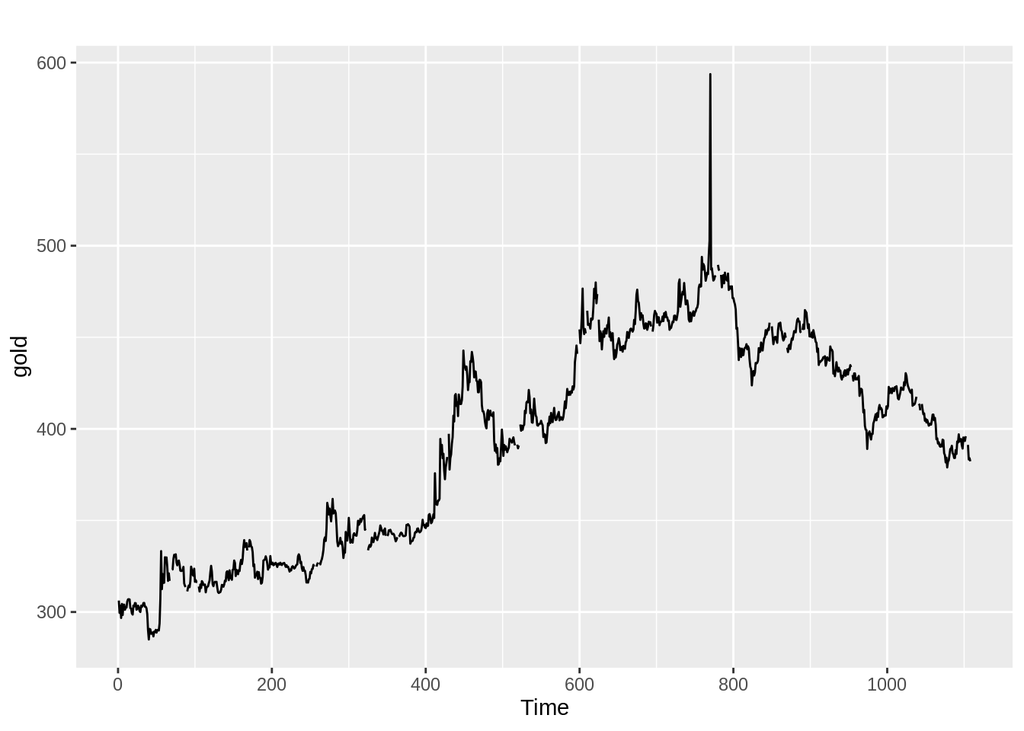

```r
autoplot(gold)
```

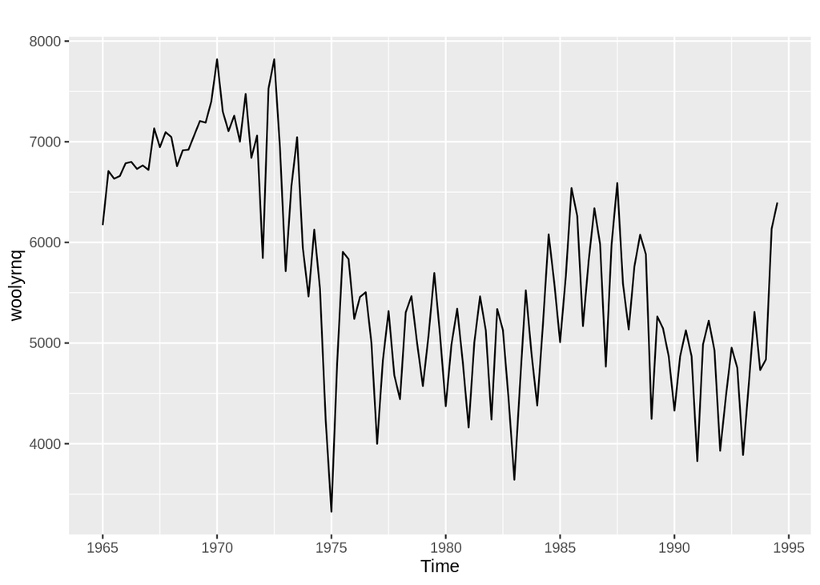

```r
autoplot(woolyrnq)
```

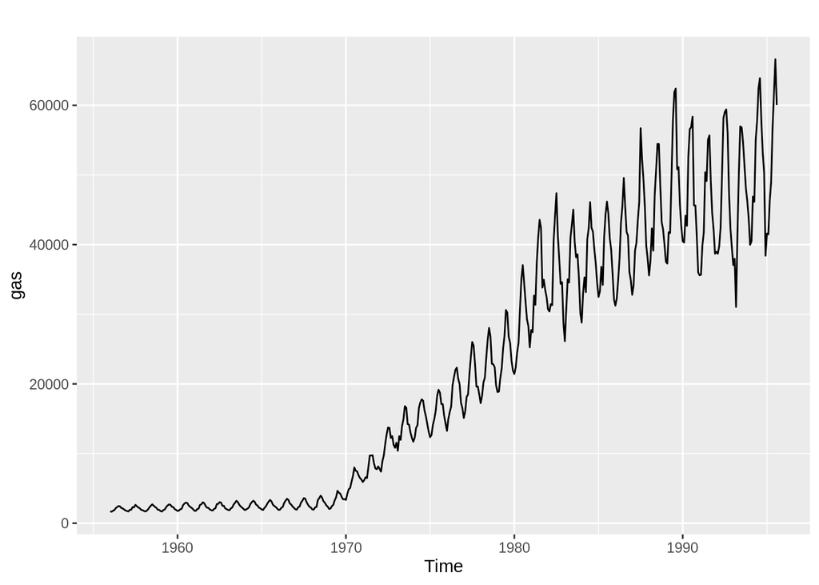

```r
autoplot(gas)
```

Gold - Timeseries plot of the price of gold Woolyrng - The quarterly production of woolen yarn in Australia in tons from March 1965 to September 1994 Gas - The monthly gas production in Australia from 1956-1995

2. What is the frequency of each series? Hint: apply the frequency() function.

```r
frequency(gold)
```

```
## [1] 1
```

```r
frequency(woolyrnq)
```

```
## [1] 4
```

```r
frequency(gas)
```

```
## [1] 12
```

The frequency is in years

- Gold - yearly
- Woolyrnq - quarterly
- Gas - monthly
3. Use which.max() to spot the outlier in the gold series. Which observation was it?

```r
summary(gold)
```

```
##    Min. 1st Qu.  Median    Mean 3rd Qu.    Max.    NA's
##   285.0   337.7   403.2   392.5   443.7   593.7      34
```

```r
which.max(gold)
```

```
## [1] 770
```

observation 770 is the outlier with value 593.7

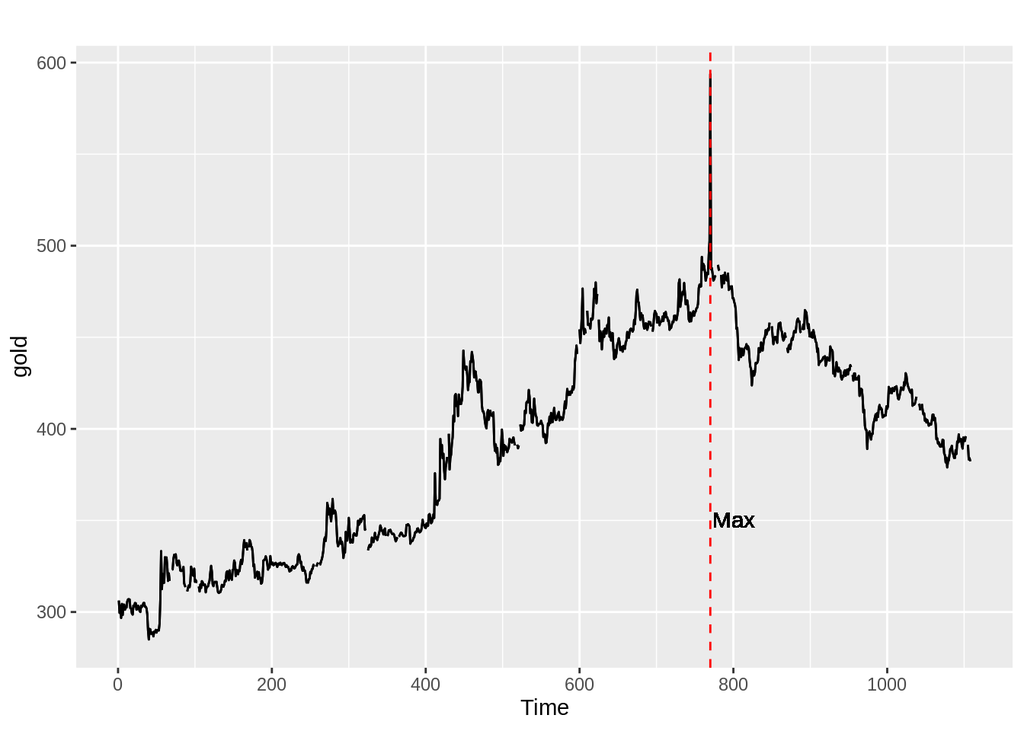

```r
autoplot(gold) + geom_line() + geom_vline(xintercept = 770, colour='red', linetype='dashed') +   geom_text(x=800, y=350, label='Max', color='black')
```

### Exercise 2.3

Download some monthly Australian retail data from the book website. These represent retail sales in various categories for different Australian states, and are stored in a MS-Excel file.

1. You can read the data into R with the following script:

```r
path <- '/home/kenan/Documents/learning/masters/CUNY-SPS-Masters-DS/DATA_624/'
rdf <- read_excel(paste0(path, 'retail.xlsx'), skip=1)
```

The second argument (skip=1) is required because the Excel sheet has two header rows.

2. Select one of the time series as follows (but replace the column name with your own chosen column):

```r
myts <- ts(rdf %>% select('A3349398A'), frequency=12, start=c(1982,4))
```

3. Explore your chosen retail time series using the following functions:

`autoplot()`, `ggseasonplot()`, `ggsubseriesplot()`, `gglagplot()`, `ggAcf()`

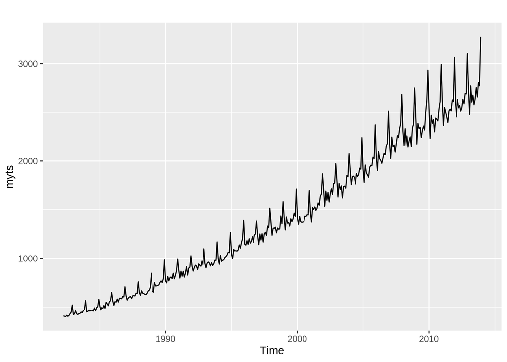

```r
autoplot(myts)
```

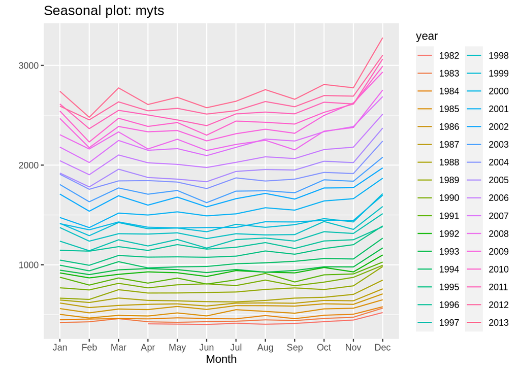

```r
ggseasonplot(myts)
```

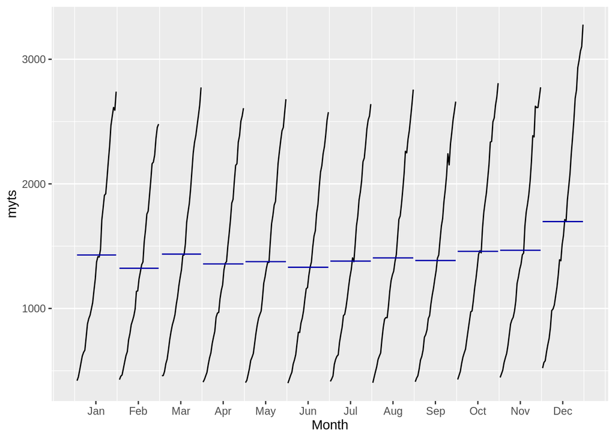

```r
ggsubseriesplot(myts)
```

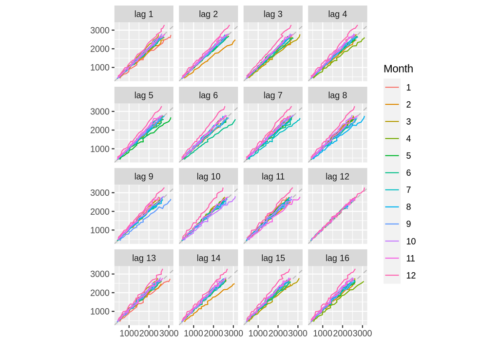

```r
gglagplot(myts)
```

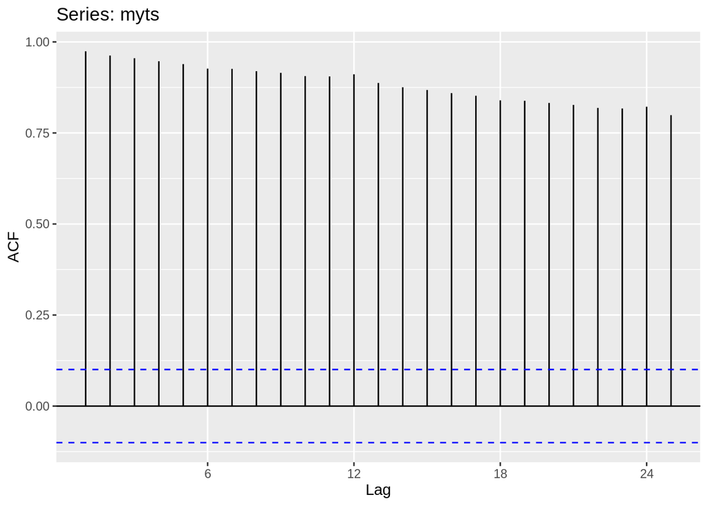

```r
ggAcf(myts)
```

Can you spot any seasonality, cyclicity and trend? What do you learn about the series?

The end of the year has the highest sales implying seasonality, most likey sales due to the holidays.

### Exercise 6.2

The plastics data set consists of the monthly sales (in thousands) of product A for a plastics manufacturer for five years.

1. Plot the time series of sales of product A. Can you identify seasonal fluctuations and/or a trend cycle?

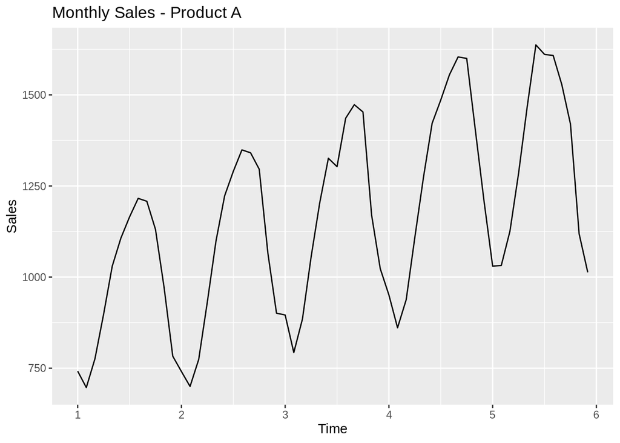

```r
autoplot(plastics) + labs(title="Monthly Sales - Product A", x="Time", y="Sales")
```

2. Use a classical multiplicative decomposition to calculate the trend-cycle and seasonal indices.

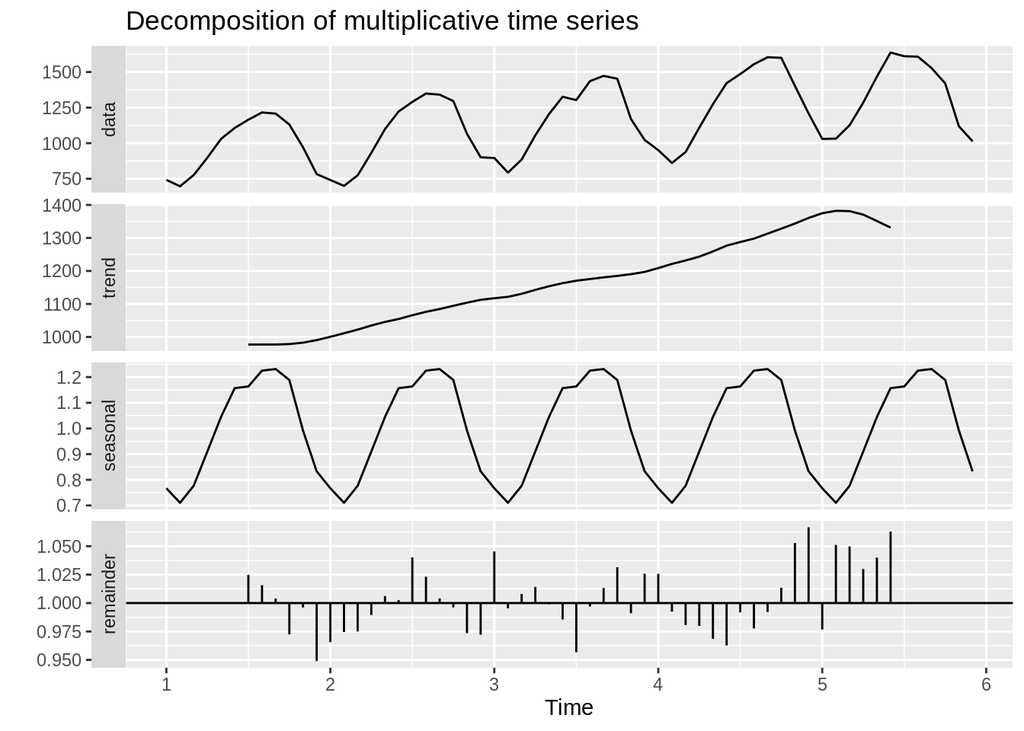

```r
plastics %>% decompose(type="multiplicative") %>% autoplot()
```

3. Do the results support the graphical interpretation from part a

The plot from part a shows an overall positive trend with seasonal fluctuations and the trend in the decompose plot verifies that.

4. Compute and plot the seasonally adjusted data.

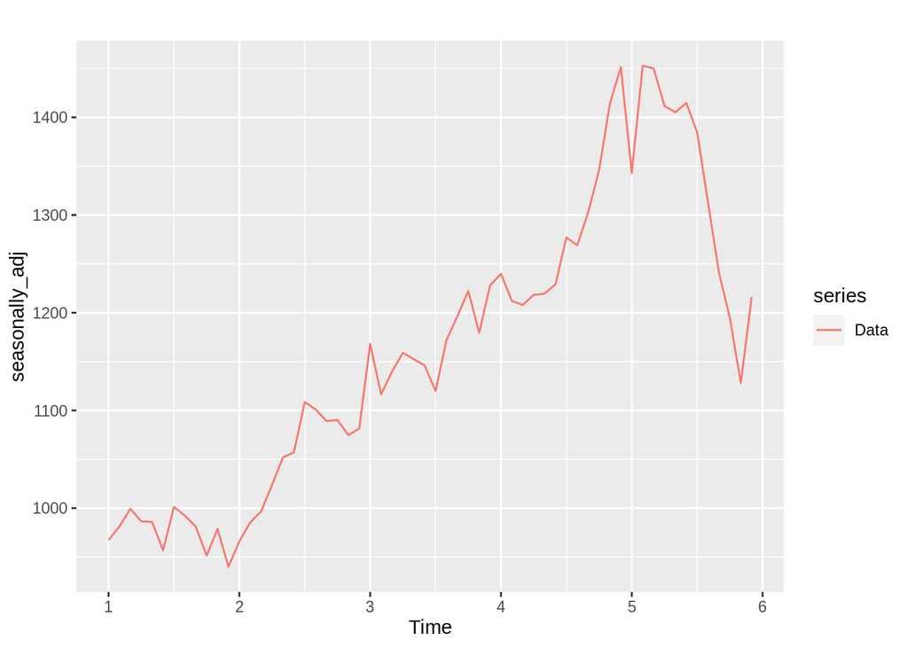

```r
seasonally_adj <- plastics / (plastics %>% decompose(type='multiplicative'))$seasonal
autoplot(seasonally_adj, series="Data")
```

5. Change one observation to be an outlier (e.g., add 500 to one observation), and recompute the seasonally adjusted data. What is the effect of the outlier?

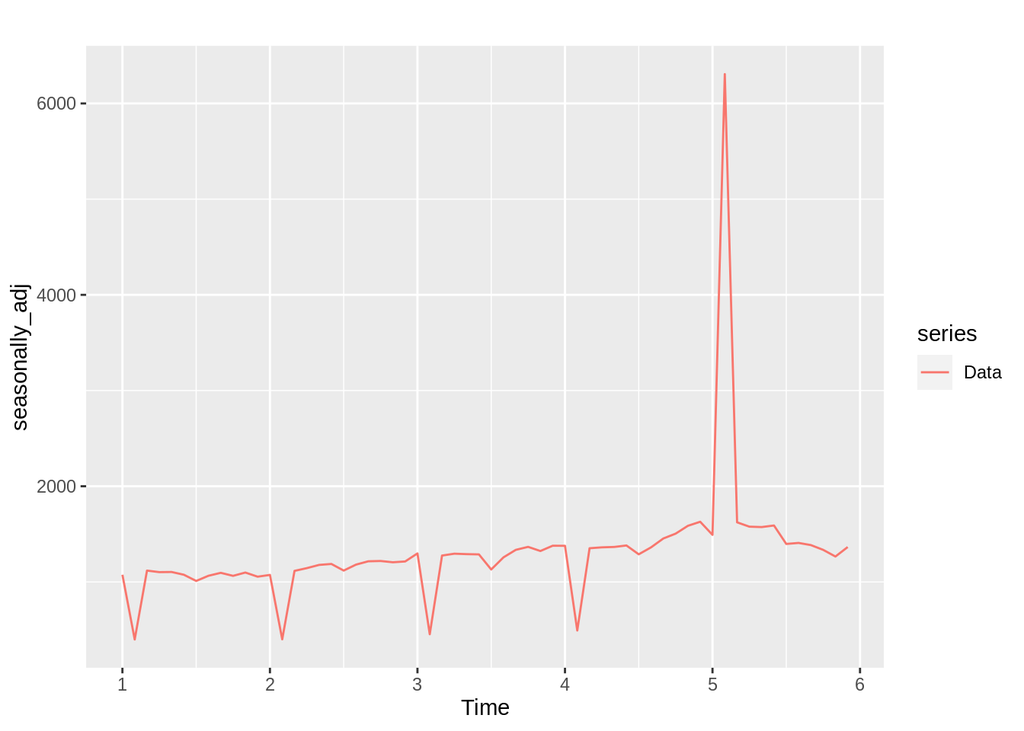

```r
tmp <- plastics[50]
plastics[50] <- plastics[50] + 9999
seasonally_adj <- plastics / (plastics %>% decompose(type='multiplicative'))$seasonal
autoplot(seasonally_adj, series="Data")
```

f . Does it make any difference if the outlier is near the end rather than in the middle of the time series?

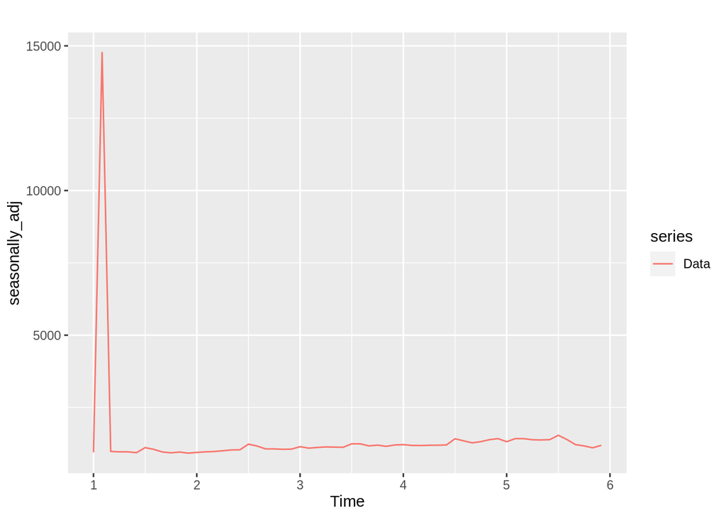

```r
plastics[50] <- tmp
plastics[2] <- plastics[2] + 9999
seasonally_adj <- plastics / (plastics %>% decompose(type='multiplicative'))$seasonal
autoplot(seasonally_adj, series="Data")
```

The outlier location makes a difference on where the spike is located. An outlier at the beginning almost completely destroyes the seasonal fluctuations.